# Part I - Ford GoBike Data Exploration

## Introduction

> This document explores a dataset containing the trip data of the Ford GoBike approximately 183,412.

## Preliminary Wrangling

While this project emphasizes communicating data findings, it's essential to first perform data wrangling to ensure the dataset is tidy and that the findings be accurate.

```python
# import all packages and set plots to be embedded inline
import numpy as np
import pandas as pd
import matplotlib.pyplot as plt
import seaborn as sb


%matplotlib inline
```

We'll first load and look at the dataset

```python
df = pd.read_csv('201902-fordgobike-tripdata.csv')
df.head()
```

|  | duration_sec | start_time | end_time | start_station_id | start_station_name | start_station_latitude | start_station_longitude | end_station_id | end_station_name | end_station_latitude | end_station_longitude | bike_id | user_type | member_birth_year | member_gender | bike_share_for_all_trip |
| --- | --- | --- | --- | --- | --- | --- | --- | --- | --- | --- | --- | --- | --- | --- | --- | --- |
| 0 | 52185 | 2019-02-28 17:32:10.1450 | 2019-03-01 08:01:55.9750 | 21.0 | Montgomery St BART Station (Market St at 2nd St) | 37.789625 | -122.400811 | 13.0 | Commercial St at Montgomery St | 37.794231 | -122.402923 | 4902 | Customer | 1984.0 | Male | No |
| 1 | 42521 | 2019-02-28 18:53:21.7890 | 2019-03-01 06:42:03.0560 | 23.0 | The Embarcadero at Steuart St | 37.791464 | -122.391034 | 81.0 | Berry St at 4th St | 37.775880 | -122.393170 | 2535 | Customer | NaN | NaN | No |
| 2 | 61854 | 2019-02-28 12:13:13.2180 | 2019-03-01 05:24:08.1460 | 86.0 | Market St at Dolores St | 37.769305 | -122.426826 | 3.0 | Powell St BART Station (Market St at 4th St) | 37.786375 | -122.404904 | 5905 | Customer | 1972.0 | Male | No |
| 3 | 36490 | 2019-02-28 17:54:26.0100 | 2019-03-01 04:02:36.8420 | 375.0 | Grove St at Masonic Ave | 37.774836 | -122.446546 | 70.0 | Central Ave at Fell St | 37.773311 | -122.444293 | 6638 | Subscriber | 1989.0 | Other | No |
| 4 | 1585 | 2019-02-28 23:54:18.5490 | 2019-03-01 00:20:44.0740 | 7.0 | Frank H Ogawa Plaza | 37.804562 | -122.271738 | 222.0 | 10th Ave at E 15th St | 37.792714 | -122.248780 | 4898 | Subscriber | 1974.0 | Male | Yes |

We'll look at the structure and contents of the DataFrame, to help identify issues like missing values or data types that may need to be adjusted.

```python
df.info()
```

```
<class 'pandas.core.frame.DataFrame'>
RangeIndex: 183412 entries, 0 to 183411
Data columns (total 16 columns):
 #   Column                   Non-Null Count   Dtype
---  ------                   --------------   -----
 0   duration_sec             183412 non-null  int64
 1   start_time               183412 non-null  object
 2   end_time                 183412 non-null  object
 3   start_station_id         183215 non-null  float64
 4   start_station_name       183215 non-null  object
 5   start_station_latitude   183412 non-null  float64
 6   start_station_longitude  183412 non-null  float64
 7   end_station_id           183215 non-null  float64
 8   end_station_name         183215 non-null  object
 9   end_station_latitude     183412 non-null  float64
 10  end_station_longitude    183412 non-null  float64
 11  bike_id                  183412 non-null  int64
 12  user_type                183412 non-null  object
 13  member_birth_year        175147 non-null  float64
 14  member_gender            175147 non-null  object
 15  bike_share_for_all_trip  183412 non-null  object
dtypes: float64(7), int64(2), object(7)
memory usage: 22.4+ MB
```

- The 'start_time' and 'end_time' fields should be changed to the datetime data type.
- The 'member_birth_year' field should be converted to an integer data type.
- The 'user_type' and 'member_gender' fields could be changed to a category data type.
- The 'bike_share_for_all_trip' field could be changed to a boolean data type.
- The 'bike_id', 'start_station_id', and 'end_station_id' fields should be changed to strings.

We'll check for duplicates

```python
sum(df.duplicated())
```

```
0
```

Next, we'll count the total number of missing (null) values in each column of a DataFrame.

```python
df.isnull().sum()
```

```
duration_sec                  0
start_time                    0
end_time                      0
start_station_id            197
start_station_name          197
start_station_latitude        0
start_station_longitude       0
end_station_id              197
end_station_name            197
end_station_latitude          0
end_station_longitude         0
bike_id                       0
user_type                     0
member_birth_year          8265
member_gender              8265
bike_share_for_all_trip       0
dtype: int64
```

Several columns contain missing data (null values)

Let's summarize a DataFrame's key statistical properties, such as count, mean, standard deviation, and quartiles.

```python
df.describe()
```

|  | duration_sec | start_station_id | start_station_latitude | start_station_longitude | end_station_id | end_station_latitude | end_station_longitude | bike_id | member_birth_year |
| --- | --- | --- | --- | --- | --- | --- | --- | --- | --- |
| count | 183412.000000 | 183215.000000 | 183412.000000 | 183412.000000 | 183215.000000 | 183412.000000 | 183412.000000 | 183412.000000 | 175147.000000 |
| mean | 726.078435 | 138.590427 | 37.771223 | -122.352664 | 136.249123 | 37.771427 | -122.352250 | 4472.906375 | 1984.806437 |
| std | 1794.389780 | 111.778864 | 0.099581 | 0.117097 | 111.515131 | 0.099490 | 0.116673 | 1664.383394 | 10.116689 |
| min | 61.000000 | 3.000000 | 37.317298 | -122.453704 | 3.000000 | 37.317298 | -122.453704 | 11.000000 | 1878.000000 |
| 25% | 325.000000 | 47.000000 | 37.770083 | -122.412408 | 44.000000 | 37.770407 | -122.411726 | 3777.000000 | 1980.000000 |
| 50% | 514.000000 | 104.000000 | 37.780760 | -122.398285 | 100.000000 | 37.781010 | -122.398279 | 4958.000000 | 1987.000000 |
| 75% | 796.000000 | 239.000000 | 37.797280 | -122.286533 | 235.000000 | 37.797320 | -122.288045 | 5502.000000 | 1992.000000 |
| max | 85444.000000 | 398.000000 | 37.880222 | -121.874119 | 398.000000 | 37.880222 | -121.874119 | 6645.000000 | 2001.000000 |

```python
df.query("member_birth_year < 1934")
```

|  | duration_sec | start_time | end_time | start_station_id | start_station_name | start_station_latitude | start_station_longitude | end_station_id | end_station_name | end_station_latitude | end_station_longitude | bike_id | user_type | member_birth_year | member_gender | bike_share_for_all_trip |
| --- | --- | --- | --- | --- | --- | --- | --- | --- | --- | --- | --- | --- | --- | --- | --- | --- |
| 1285 | 148 | 2019-02-28 19:29:17.6270 | 2019-02-28 19:31:45.9670 | 158.0 | Shattuck Ave at Telegraph Ave | 37.833279 | -122.263490 | 173.0 | Shattuck Ave at 55th St | 37.840364 | -122.264488 | 5391 | Subscriber | 1900.0 | Male | Yes |
| 5197 | 217 | 2019-02-28 13:51:46.2380 | 2019-02-28 13:55:24.1270 | 70.0 | Central Ave at Fell St | 37.773311 | -122.444293 | 71.0 | Broderick St at Oak St | 37.773063 | -122.439078 | 5801 | Subscriber | 1931.0 | Male | No |
| 5266 | 384 | 2019-02-28 13:35:05.4280 | 2019-02-28 13:41:30.2230 | 84.0 | Duboce Park | 37.769200 | -122.433812 | 71.0 | Broderick St at Oak St | 37.773063 | -122.439078 | 6608 | Subscriber | 1931.0 | Male | No |
| 5447 | 147 | 2019-02-28 13:08:56.9350 | 2019-02-28 13:11:24.0620 | 84.0 | Duboce Park | 37.769200 | -122.433812 | 72.0 | Page St at Scott St | 37.772406 | -122.435650 | 5018 | Subscriber | 1931.0 | Male | No |
| 10827 | 1315 | 2019-02-27 19:21:34.4360 | 2019-02-27 19:43:30.0080 | 343.0 | Bryant St at 2nd St | 37.783172 | -122.393572 | 375.0 | Grove St at Masonic Ave | 37.774836 | -122.446546 | 6249 | Subscriber | 1900.0 | Male | No |
| ... | ... | ... | ... | ... | ... | ... | ... | ... | ... | ... | ... | ... | ... | ... | ... | ... |
| 177708 | 1527 | 2019-02-01 19:09:28.3870 | 2019-02-01 19:34:55.9630 | 343.0 | Bryant St at 2nd St | 37.783172 | -122.393572 | 375.0 | Grove St at Masonic Ave | 37.774836 | -122.446546 | 5286 | Subscriber | 1900.0 | Male | No |
| 177885 | 517 | 2019-02-01 18:38:40.4710 | 2019-02-01 18:47:18.3920 | 25.0 | Howard St at 2nd St | 37.787522 | -122.397405 | 30.0 | San Francisco Caltrain (Townsend St at 4th St) | 37.776598 | -122.395282 | 2175 | Subscriber | 1902.0 | Female | No |
| 177955 | 377 | 2019-02-01 18:23:33.4110 | 2019-02-01 18:29:50.7950 | 26.0 | 1st St at Folsom St | 37.787290 | -122.394380 | 321.0 | 5th St at Folsom | 37.780146 | -122.403071 | 5444 | Subscriber | 1933.0 | Female | Yes |
| 182830 | 428 | 2019-02-01 07:45:05.9340 | 2019-02-01 07:52:14.9220 | 284.0 | Yerba Buena Center for the Arts (Howard St at ... | 37.784872 | -122.400876 | 67.0 | San Francisco Caltrain Station 2 (Townsend St... | 37.776639 | -122.395526 | 5031 | Subscriber | 1901.0 | Male | No |
| 183388 | 490 | 2019-02-01 00:39:53.1120 | 2019-02-01 00:48:03.3380 | 61.0 | Howard St at 8th St | 37.776513 | -122.411306 | 81.0 | Berry St at 4th St | 37.775880 | -122.393170 | 5411 | Subscriber | 1927.0 | Male | No |

187 rows × 16 columns

### Data Cleaning

The initial step in the cleaning process involved making a copy of the original dataset.

```python
# make a copy
df_clean = df.copy()
```

We'll remove the null values from the dataset and reset the index

```python
# dropping rows with null values
df_clean.dropna(inplace=True)
```

```python
df_clean.reset_index(drop=True, inplace = True)
```

Let's review the dataset overview to see the changes

```python
# Display DataFrame info
df_clean.info()

# Check for null counts
null_counts = df_clean.isnull().sum()
print(null_counts)
```

```
<class 'pandas.core.frame.DataFrame'>
RangeIndex: 174952 entries, 0 to 174951
Data columns (total 16 columns):
 #   Column                   Non-Null Count   Dtype
---  ------                   --------------   -----
 0   duration_sec             174952 non-null  int64
 1   start_time               174952 non-null  object
 2   end_time                 174952 non-null  object
 3   start_station_id         174952 non-null  float64
 4   start_station_name       174952 non-null  object
 5   start_station_latitude   174952 non-null  float64
 6   start_station_longitude  174952 non-null  float64
 7   end_station_id           174952 non-null  float64
 8   end_station_name         174952 non-null  object
 9   end_station_latitude     174952 non-null  float64
 10  end_station_longitude    174952 non-null  float64
 11  bike_id                  174952 non-null  int64
 12  user_type                174952 non-null  object
 13  member_birth_year        174952 non-null  float64
 14  member_gender            174952 non-null  object
 15  bike_share_for_all_trip  174952 non-null  object
dtypes: float64(7), int64(2), object(7)
memory usage: 21.4+ MB
duration_sec               0
start_time                 0
end_time                   0
start_station_id           0
start_station_name         0
start_station_latitude     0
start_station_longitude    0
end_station_id             0
end_station_name           0
end_station_latitude       0
end_station_longitude      0
bike_id                    0
user_type                  0
member_birth_year          0
member_gender              0
bike_share_for_all_trip    0
dtype: int64
```

Next, we'll change the datatypes that we mentioned before

```python
# Define a dictionary of columns and their desired data types
dtype_mapping = {
    'start_time': 'datetime64[ns]',
    'end_time': 'datetime64[ns]',
    'member_birth_year': 'int',
    'bike_id': 'object',
    'start_station_id': 'object',
    'end_station_id': 'object',
    'user_type': 'category',
    'member_gender': 'category',
    'bike_share_for_all_trip': 'category'
}

# Apply the conversions
for column, dtype in dtype_mapping.items():
    df_clean[column] = df_clean[column].astype(dtype)
```

Let's check the overview of the dataframe

```python
df_clean.info()
```

```
<class 'pandas.core.frame.DataFrame'>
RangeIndex: 174952 entries, 0 to 174951
Data columns (total 16 columns):
 #   Column                   Non-Null Count   Dtype
---  ------                   --------------   -----
 0   duration_sec             174952 non-null  int64
 1   start_time               174952 non-null  datetime64[ns]
 2   end_time                 174952 non-null  datetime64[ns]
 3   start_station_id         174952 non-null  object
 4   start_station_name       174952 non-null  object
 5   start_station_latitude   174952 non-null  float64
 6   start_station_longitude  174952 non-null  float64
 7   end_station_id           174952 non-null  object
 8   end_station_name         174952 non-null  object
 9   end_station_latitude     174952 non-null  float64
 10  end_station_longitude    174952 non-null  float64
 11  bike_id                  174952 non-null  object
 12  user_type                174952 non-null  category
 13  member_birth_year        174952 non-null  int64
 14  member_gender            174952 non-null  category
 15  bike_share_for_all_trip  174952 non-null  category
dtypes: category(3), datetime64[ns](2), float64(4), int64(2), object(5)
memory usage: 17.9+ MB
```

Let's take a look at the statistics for the member birth years in the dataset.

```python
df_clean.member_birth_year.describe()
```

```
count    174952.000000
mean       1984.803135
std          10.118731
min        1878.000000
25%        1980.000000
50%        1987.000000
75%        1992.000000
max        2001.000000
Name: member_birth_year, dtype: float64
```

Let's look at a histogram of member birth years, using 5-year bins from 1880 to 2000 to visualize the frequency distribution of the data.

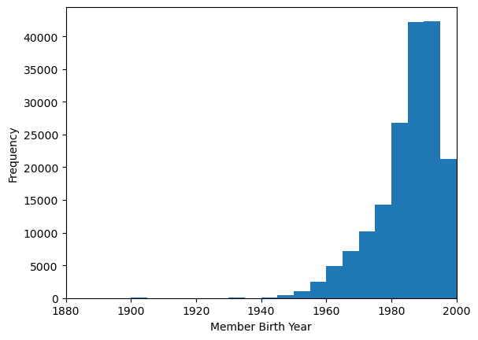

```python
bin_edges = np.arange (0, df_clean['member_birth_year'].max()+5, 5)
plt.hist(data = df_clean, x = 'member_birth_year', bins = bin_edges)
plt.xlim(1880, 2000)
plt.xlabel('Member Birth Year')
plt.ylabel('Frequency');
```

Next, we'll look for outliers in member birth years by visualizing the data with a box plot.

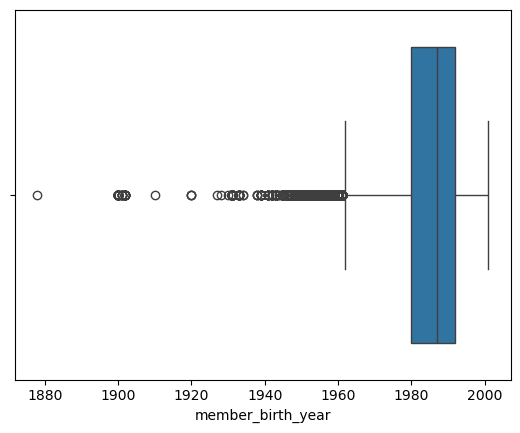

```python
# look for outliers
sb.boxplot(x=df_clean['member_birth_year'])
```

Let's calculate the first and third quartiles (Q1 and Q3) and the interquartile range (IQR) for member birth years to identify potential outliers.

```python
# Using the Interquartile Range to understand outliers
q1 = df_clean.member_birth_year.quantile(0.25)
q3 = df_clean.member_birth_year.quantile(0.75)
iqr = q3 - q1
print(q1)
print(q3)
print(iqr)
```

```
1980.0
1992.0
12.0
```

We'll calculate the lower whisker for identifying outliers in member birth years, which is determined by subtracting 1.5 times the interquartile range (IQR) from Q1.

```python
lower_whisker = q1 - 1.5 * iqr
print(lower_whisker)
```

```
1962.0
```

Let's filter the dataset to examine members born before 1962.

```python
df_clean.query("member_birth_year < 1962")
```

|  | duration_sec | start_time | end_time | start_station_id | start_station_name | start_station_latitude | start_station_longitude | end_station_id | end_station_name | end_station_latitude | end_station_longitude | bike_id | user_type | member_birth_year | member_gender | bike_share_for_all_trip |
| --- | --- | --- | --- | --- | --- | --- | --- | --- | --- | --- | --- | --- | --- | --- | --- | --- |
| 4 | 1793 | 2019-02-28 23:49:58.632 | 2019-03-01 00:19:51.760 | 93.0 | 4th St at Mission Bay Blvd S | 37.770407 | -122.391198 | 323.0 | Broadway at Kearny | 37.798014 | -122.405950 | 5200 | Subscriber | 1959 | Male | No |
| 40 | 116 | 2019-02-28 23:44:00.988 | 2019-02-28 23:45:57.482 | 104.0 | 4th St at 16th St | 37.767045 | -122.390833 | 93.0 | 4th St at Mission Bay Blvd S | 37.770407 | -122.391198 | 823 | Subscriber | 1959 | Male | No |
| 62 | 681 | 2019-02-28 23:19:37.366 | 2019-02-28 23:30:58.862 | 43.0 | San Francisco Public Library (Grove St at Hyde... | 37.778768 | -122.415929 | 70.0 | Central Ave at Fell St | 37.773311 | -122.444293 | 6333 | Subscriber | 1959 | Male | No |
| 196 | 547 | 2019-02-28 22:25:51.137 | 2019-02-28 22:34:58.970 | 76.0 | McCoppin St at Valencia St | 37.771662 | -122.422423 | 43.0 | San Francisco Public Library (Grove St at Hyde... | 37.778768 | -122.415929 | 6333 | Subscriber | 1961 | Female | No |
| 297 | 217 | 2019-02-28 21:58:47.639 | 2019-02-28 22:02:24.693 | 149.0 | Emeryville Town Hall | 37.831275 | -122.285633 | 153.0 | 59th St at Horton St | 37.840945 | -122.291360 | 5210 | Subscriber | 1961 | Male | No |
| ... | ... | ... | ... | ... | ... | ... | ... | ... | ... | ... | ... | ... | ... | ... | ... | ... |
| 174844 | 459 | 2019-02-01 05:15:05.178 | 2019-02-01 05:22:44.272 | 104.0 | 4th St at 16th St | 37.767045 | -122.390833 | 30.0 | San Francisco Caltrain (Townsend St at 4th St) | 37.776598 | -122.395282 | 3446 | Subscriber | 1959 | Male | No |
| 174852 | 373 | 2019-02-01 04:42:44.709 | 2019-02-01 04:48:58.076 | 131.0 | 22nd St at Dolores St | 37.755000 | -122.425728 | 129.0 | Harrison St at 20th St | 37.758862 | -122.412544 | 5427 | Subscriber | 1958 | Male | No |
| 174853 | 100 | 2019-02-01 04:46:54.805 | 2019-02-01 04:48:34.843 | 80.0 | Townsend St at 5th St | 37.775235 | -122.397437 | 67.0 | San Francisco Caltrain Station 2 (Townsend St... | 37.776639 | -122.395526 | 3138 | Subscriber | 1950 | Male | No |
| 174926 | 400 | 2019-02-01 00:46:47.276 | 2019-02-01 00:53:27.596 | 220.0 | San Pablo Ave at MLK Jr Way | 37.811351 | -122.273422 | 337.0 | Webster St at 19th St | 37.806970 | -122.266588 | 3487 | Subscriber | 1945 | Male | Yes |
| 174929 | 490 | 2019-02-01 00:39:53.112 | 2019-02-01 00:48:03.338 | 61.0 | Howard St at 8th St | 37.776513 | -122.411306 | 81.0 | Berry St at 4th St | 37.775880 | -122.393170 | 5411 | Subscriber | 1927 | Male | No |

5781 rows × 16 columns

Lets look at the bottom 1% of birth years

```python
df.member_birth_year.describe(percentiles = [.01])
```

```
count    175147.000000
mean       1984.806437
std          10.116689
min        1878.000000
1%         1955.000000
50%        1987.000000
max        2001.000000
Name: member_birth_year, dtype: float64
```

We'll look for birth years prior to 1955.

```python
df_clean.query("member_birth_year < 1955")
```

|  | duration_sec | start_time | end_time | start_station_id | start_station_name | start_station_latitude | start_station_longitude | end_station_id | end_station_name | end_station_latitude | end_station_longitude | bike_id | user_type | member_birth_year | member_gender | bike_share_for_all_trip |
| --- | --- | --- | --- | --- | --- | --- | --- | --- | --- | --- | --- | --- | --- | --- | --- | --- |
| 476 | 235 | 2019-02-28 21:17:57.047 | 2019-02-28 21:21:52.631 | 34.0 | Father Alfred E Boeddeker Park | 37.783988 | -122.412408 | 58.0 | Market St at 10th St | 37.776619 | -122.417385 | 5202 | Subscriber | 1954 | Male | No |
| 956 | 384 | 2019-02-28 19:56:45.837 | 2019-02-28 20:03:10.473 | 250.0 | North Berkeley BART Station | 37.873558 | -122.283093 | 257.0 | Fifth St at Delaware St | 37.870407 | -122.299676 | 1671 | Subscriber | 1954 | Male | No |
| 1033 | 303 | 2019-02-28 19:49:38.120 | 2019-02-28 19:54:42.044 | 43.0 | San Francisco Public Library (Grove St at Hyde... | 37.778768 | -122.415929 | 76.0 | McCoppin St at Valencia St | 37.771662 | -122.422423 | 6333 | Subscriber | 1945 | Male | Yes |
| 1238 | 148 | 2019-02-28 19:29:17.627 | 2019-02-28 19:31:45.967 | 158.0 | Shattuck Ave at Telegraph Ave | 37.833279 | -122.263490 | 173.0 | Shattuck Ave at 55th St | 37.840364 | -122.264488 | 5391 | Subscriber | 1900 | Male | Yes |
| 1295 | 1362 | 2019-02-28 19:02:33.643 | 2019-02-28 19:25:16.561 | 15.0 | San Francisco Ferry Building (Harry Bridges Pl... | 37.795392 | -122.394203 | 97.0 | 14th St at Mission St | 37.768265 | -122.420110 | 48 | Subscriber | 1954 | Male | No |
| ... | ... | ... | ... | ... | ... | ... | ... | ... | ... | ... | ... | ... | ... | ... | ... | ... |
| 174773 | 191 | 2019-02-01 06:32:38.467 | 2019-02-01 06:35:50.222 | 15.0 | San Francisco Ferry Building (Harry Bridges Pl... | 37.795392 | -122.394203 | 20.0 | Mechanics Monument Plaza (Market St at Bush St) | 37.791300 | -122.399051 | 3108 | Subscriber | 1947 | Male | No |
| 174808 | 966 | 2019-02-01 05:57:01.688 | 2019-02-01 06:13:08.313 | 126.0 | Esprit Park | 37.761634 | -122.390648 | 16.0 | Steuart St at Market St | 37.794130 | -122.394430 | 1338 | Subscriber | 1952 | Male | No |
| 174853 | 100 | 2019-02-01 04:46:54.805 | 2019-02-01 04:48:34.843 | 80.0 | Townsend St at 5th St | 37.775235 | -122.397437 | 67.0 | San Francisco Caltrain Station 2 (Townsend St... | 37.776639 | -122.395526 | 3138 | Subscriber | 1950 | Male | No |
| 174926 | 400 | 2019-02-01 00:46:47.276 | 2019-02-01 00:53:27.596 | 220.0 | San Pablo Ave at MLK Jr Way | 37.811351 | -122.273422 | 337.0 | Webster St at 19th St | 37.806970 | -122.266588 | 3487 | Subscriber | 1945 | Male | Yes |
| 174929 | 490 | 2019-02-01 00:39:53.112 | 2019-02-01 00:48:03.338 | 61.0 | Howard St at 8th St | 37.776513 | -122.411306 | 81.0 | Berry St at 4th St | 37.775880 | -122.393170 | 5411 | Subscriber | 1927 | Male | No |

1680 rows × 16 columns

We will remove these instead and reset the index

```python
df_clean.drop(df_clean[df_clean.member_birth_year < 1955].index, inplace=True)
```

```python
df_clean.reset_index(drop=True, inplace = True)
```

Check if there are any records after removing them

```python
df_clean.query("member_birth_year < 1955")
```

|  | duration_sec | start_time | end_time | start_station_id | start_station_name | start_station_latitude | start_station_longitude | end_station_id | end_station_name | end_station_latitude | end_station_longitude | bike_id | user_type | member_birth_year | member_gender | bike_share_for_all_trip |
| --- | --- | --- | --- | --- | --- | --- | --- | --- | --- | --- | --- | --- | --- | --- | --- | --- |

We'll look at overview of the dataframe again and check for nulls

```python
# Display DataFrame info
df_clean.info()

# Check for null counts
null_counts = df_clean.isnull().sum()
print(null_counts)
```

```
<class 'pandas.core.frame.DataFrame'>
RangeIndex: 173272 entries, 0 to 173271
Data columns (total 16 columns):
 #   Column                   Non-Null Count   Dtype
---  ------                   --------------   -----
 0   duration_sec             173272 non-null  int64
 1   start_time               173272 non-null  datetime64[ns]
 2   end_time                 173272 non-null  datetime64[ns]
 3   start_station_id         173272 non-null  object
 4   start_station_name       173272 non-null  object
 5   start_station_latitude   173272 non-null  float64
 6   start_station_longitude  173272 non-null  float64
 7   end_station_id           173272 non-null  object
 8   end_station_name         173272 non-null  object
 9   end_station_latitude     173272 non-null  float64
 10  end_station_longitude    173272 non-null  float64
 11  bike_id                  173272 non-null  object
 12  user_type                173272 non-null  category
 13  member_birth_year        173272 non-null  int64
 14  member_gender            173272 non-null  category
 15  bike_share_for_all_trip  173272 non-null  category
dtypes: category(3), datetime64[ns](2), float64(4), int64(2), object(5)
memory usage: 17.7+ MB
duration_sec               0
start_time                 0
end_time                   0
start_station_id           0
start_station_name         0
start_station_latitude     0
start_station_longitude    0
end_station_id             0
end_station_name           0
end_station_latitude       0
end_station_longitude      0
bike_id                    0
user_type                  0
member_birth_year          0
member_gender              0
bike_share_for_all_trip    0
dtype: int64
```

```python
df_clean.describe()
```

|  | duration_sec | start_time | end_time | start_station_latitude | start_station_longitude | end_station_latitude | end_station_longitude | member_birth_year |
| --- | --- | --- | --- | --- | --- | --- | --- | --- |
| count | 173272.000000 | 173272 | 173272 | 173272.000000 | 173272.000000 | 173272.000000 | 173272.000000 | 173272.000000 |
| mean | 703.878549 | 2019-02-15 21:21:32.505712128 | 2019-02-15 21:33:16.883208960 | 37.771060 | -122.351657 | 37.771257 | -122.351228 | 1985.171747 |
| min | 61.000000 | 2019-02-01 00:00:20.636000 | 2019-02-01 00:04:52.058000 | 37.317298 | -122.453704 | 37.317298 | -122.453704 | 1955.000000 |
| 25% | 323.000000 | 2019-02-08 08:30:43.535000064 | 2019-02-08 08:41:02.230500096 | 37.770407 | -122.411901 | 37.770407 | -122.411647 | 1980.000000 |
| 50% | 510.000000 | 2019-02-15 21:32:02.059000064 | 2019-02-15 21:45:20.187500032 | 37.780760 | -122.398279 | 37.781010 | -122.397437 | 1987.000000 |
| 75% | 788.000000 | 2019-02-22 11:19:06.316000 | 2019-02-22 11:33:13.886749952 | 37.797320 | -122.283093 | 37.797673 | -122.286533 | 1992.000000 |
| max | 84548.000000 | 2019-02-28 23:59:18.548000 | 2019-03-01 08:01:55.975000 | 37.880222 | -121.874119 | 37.880222 | -121.874119 | 2001.000000 |
| std | 1647.305625 | NaN | NaN | 0.100682 | 0.118001 | 0.100587 | 0.117560 | 9.378430 |

### What is the structure of your dataset?

> The dataset has 173,272 entries after cleaning the data. The dataset contains these features:
- duration_sec
- start_time
- end_time
- start_station_id
- start_station_name
- start_station_latitude
- start_station_longitude
- end_station_id
- end_station_name
- end_station_latitude
- end_ station_longitude
- bike_id
- user_type
- member_birth_year
- member_gender
- bike_share_for_all_trip

### What is/are the main feature(s) of interest in your dataset?

> The main features of interest in the dataset are those that effectively predict bike trip duration and influence trip frequency. Understanding these key factors will help us identify the most significant predictors for both aspects of bike usage.

### What features in the dataset do you think will help support your investigation into your feature(s) of interest?

In my investigation into the features of interest regarding bike rides, I anticipate that the following dataset features will provide valuable insights:

- Time of Day: I expect this feature to significantly influence both the frequency and duration of bike rides, with peak usage occurring during commuting hours.
- Day of the Week: Similar to time of day, this feature is likely to affect ride patterns, with certain days showing higher activity levels.
- User Type: Differentiating between subscribers and customers will help in understanding how user engagement affects riding behavior.
- Member Birth Year: Analyzing the birth year of riders may provide insights into generational differences in bike usage.
- Gender: Exploring the relationship between gender and ride frequency/duration will help identify any disparities in bike usage patterns.

These features collectively will support a comprehensive analysis of the factors influencing bike ride behavior.

## Univariate Exploration

In this section, we will analyze the distributions of individual variables. First, we’ll focus on the distribution of bike trip durations.

Here, we'll create a histogram of trip durations in seconds

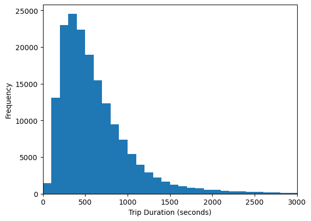

```python
bin_edges = np.arange (0, df_clean['duration_sec'].max()+100, 100)
plt.hist(data = df_clean, x = 'duration_sec', bins = bin_edges)
plt.xlim(0, 3000)
plt.xlabel('Trip Duration (seconds)')
plt.ylabel('Frequency');
```

From this histogram, we see frequency distribution of trip durations, with most trips lasting between 0 and 1000 seconds, and the frequency sharply decreasing for longer durations.

```python
# gauging bin limits are appropriate for the plot
df_clean['duration_sec'].describe()
```

```
count    173272.000000
mean        703.878549
std        1647.305625
min          61.000000
25%         323.000000
50%         510.000000
75%         788.000000
max       84548.000000
Name: duration_sec, dtype: float64
```

The data follows a highly skewed, long-tailed distribution, with most trip durations under 1,000 seconds. To gain clearer insights, a logarithmic transformation is appropriate.

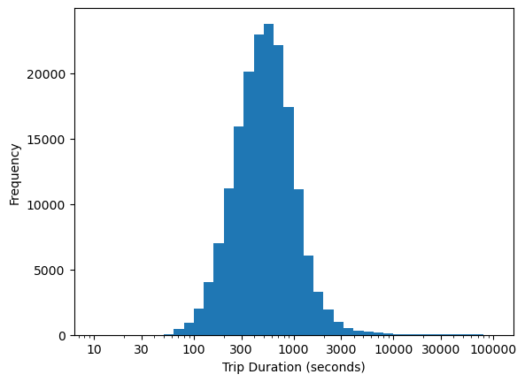

```python
bin_edges = 10 ** np.arange(1, 5 + 0.1, 0.1)
ticks = [10, 30, 100, 300, 1000, 3000, 10000, 30000, 100000]
plt.hist(data = df_clean, x = 'duration_sec', bins=bin_edges)
plt.xscale('log')
plt.xticks(ticks, ticks)
plt.xlabel('Trip Duration (seconds)')
plt.ylabel('Frequency');
```

On a logarithmic scale, the duration of bike trips appears quite standard, showing a prominent peak near 650 seconds. To enhance the clarity of our findings, it would be beneficial to include an additional column that presents bike trip durations in minutes, as this format is generally easier for people to understand than seconds.

```python
# create a duration column in minutes
df_clean['duration_min'] = df_clean['duration_sec'] / 60
```

Histogram of trip duration in minutes

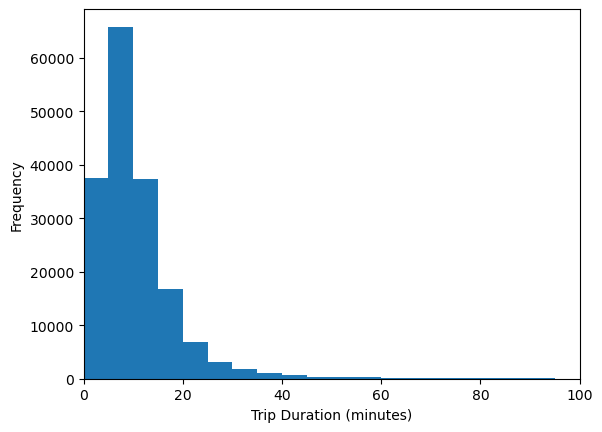

```python
bin_edges = np.arange (0, df_clean['duration_min'].max()+5, 5)
plt.hist(data = df_clean, x = 'duration_min', bins = bin_edges)
plt.xlim(0, 100)
plt.xlabel('Trip Duration (minutes)')
plt.ylabel('Frequency');
```

Since the data shows a strong skew when expressed in seconds, using a logarithmic scale is again the most suitable option.

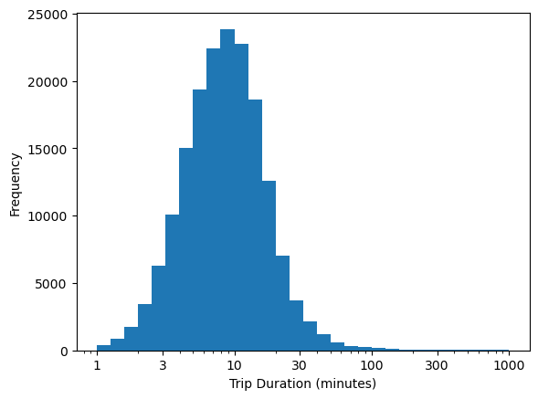

```python
bin_edges = 10 ** np.arange(0, 3 + 0.1, 0.1)
ticks = [1, 3, 10, 30, 100, 300, 1000]
plt.hist(data = df_clean, x = 'duration_min', bins=bin_edges)
plt.xscale('log')
plt.xticks(ticks, ticks)
plt.xlabel('Trip Duration (minutes)')
plt.ylabel('Frequency');
```

When we look at the bike trip durations on a log scale in minutes, we see a peak around 9 to 10 minutes.

We'll take a look at the the time of day feature by extracting the start hour from the start time

```python
# extract the start hour of the trip from the start time column
df_clean['start_hour'] = df_clean['start_time'].dt.strftime('%H')
```

```python
df_clean['start_hour'] = df_clean['start_hour'].astype(int)
```

```python
# test
df_clean.head()
```

|  | duration_sec | start_time | end_time | start_station_id | start_station_name | start_station_latitude | start_station_longitude | end_station_id | end_station_name | end_station_latitude | end_station_longitude | bike_id | user_type | member_birth_year | member_gender | bike_share_for_all_trip | duration_min | start_hour |
| --- | --- | --- | --- | --- | --- | --- | --- | --- | --- | --- | --- | --- | --- | --- | --- | --- | --- | --- |
| 0 | 52185 | 2019-02-28 17:32:10.145 | 2019-03-01 08:01:55.975 | 21.0 | Montgomery St BART Station (Market St at 2nd St) | 37.789625 | -122.400811 | 13.0 | Commercial St at Montgomery St | 37.794231 | -122.402923 | 4902 | Customer | 1984 | Male | No | 869.750000 | 17 |
| 1 | 61854 | 2019-02-28 12:13:13.218 | 2019-03-01 05:24:08.146 | 86.0 | Market St at Dolores St | 37.769305 | -122.426826 | 3.0 | Powell St BART Station (Market St at 4th St) | 37.786375 | -122.404904 | 5905 | Customer | 1972 | Male | No | 1030.900000 | 12 |
| 2 | 36490 | 2019-02-28 17:54:26.010 | 2019-03-01 04:02:36.842 | 375.0 | Grove St at Masonic Ave | 37.774836 | -122.446546 | 70.0 | Central Ave at Fell St | 37.773311 | -122.444293 | 6638 | Subscriber | 1989 | Other | No | 608.166667 | 17 |
| 3 | 1585 | 2019-02-28 23:54:18.549 | 2019-03-01 00:20:44.074 | 7.0 | Frank H Ogawa Plaza | 37.804562 | -122.271738 | 222.0 | 10th Ave at E 15th St | 37.792714 | -122.248780 | 4898 | Subscriber | 1974 | Male | Yes | 26.416667 | 23 |
| 4 | 1793 | 2019-02-28 23:49:58.632 | 2019-03-01 00:19:51.760 | 93.0 | 4th St at Mission Bay Blvd S | 37.770407 | -122.391198 | 323.0 | Broadway at Kearny | 37.798014 | -122.405950 | 5200 | Subscriber | 1959 | Male | No | 29.883333 | 23 |

We will create a countplot showing the frequency of bike rides by hour of the day.

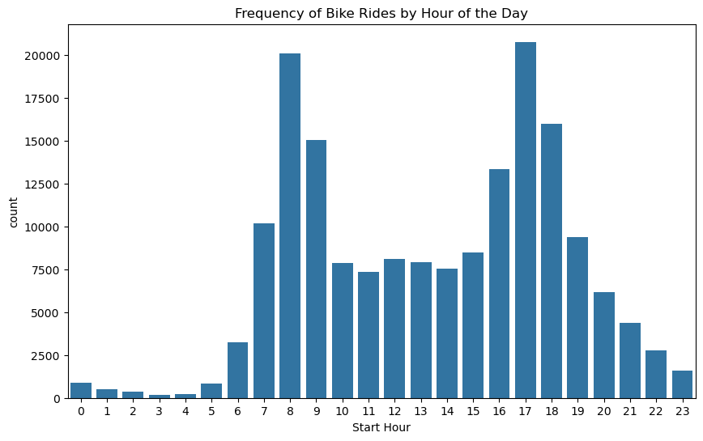

```python
# plot the frequency of bike rides by hour of the day
plt.figure(figsize=[10,6])
base_color = sb.color_palette()[0]
sb.countplot(data = df_clean, x = 'start_hour', color = base_color)
plt.xlabel('Start Hour')
plt.title('Frequency of Bike Rides by Hour of the Day')
```

The visualization demonstrates a significant increase in bike trips during the morning rush from 7 to 9 AM and in the evening from 4 to 7 PM.

To gain further insights, we'll extract the day of the week to see if these patterns align with weekday commuting behavior.

```python
# extracting the day of the week from the start_time column
df_clean['day'] = df_clean['start_time'].dt.strftime('%A')
```

Let's check the dataframe for the changes

```python
df_clean
```

|  | duration_sec | start_time | end_time | start_station_id | start_station_name | start_station_latitude | start_station_longitude | end_station_id | end_station_name | end_station_latitude | end_station_longitude | bike_id | user_type | member_birth_year | member_gender | bike_share_for_all_trip | duration_min | start_hour | day |
| --- | --- | --- | --- | --- | --- | --- | --- | --- | --- | --- | --- | --- | --- | --- | --- | --- | --- | --- | --- |
| 0 | 52185 | 2019-02-28 17:32:10.145 | 2019-03-01 08:01:55.975 | 21.0 | Montgomery St BART Station (Market St at 2nd St) | 37.789625 | -122.400811 | 13.0 | Commercial St at Montgomery St | 37.794231 | -122.402923 | 4902 | Customer | 1984 | Male | No | 869.750000 | 17 | Thursday |
| 1 | 61854 | 2019-02-28 12:13:13.218 | 2019-03-01 05:24:08.146 | 86.0 | Market St at Dolores St | 37.769305 | -122.426826 | 3.0 | Powell St BART Station (Market St at 4th St) | 37.786375 | -122.404904 | 5905 | Customer | 1972 | Male | No | 1030.900000 | 12 | Thursday |
| 2 | 36490 | 2019-02-28 17:54:26.010 | 2019-03-01 04:02:36.842 | 375.0 | Grove St at Masonic Ave | 37.774836 | -122.446546 | 70.0 | Central Ave at Fell St | 37.773311 | -122.444293 | 6638 | Subscriber | 1989 | Other | No | 608.166667 | 17 | Thursday |
| 3 | 1585 | 2019-02-28 23:54:18.549 | 2019-03-01 00:20:44.074 | 7.0 | Frank H Ogawa Plaza | 37.804562 | -122.271738 | 222.0 | 10th Ave at E 15th St | 37.792714 | -122.248780 | 4898 | Subscriber | 1974 | Male | Yes | 26.416667 | 23 | Thursday |
| 4 | 1793 | 2019-02-28 23:49:58.632 | 2019-03-01 00:19:51.760 | 93.0 | 4th St at Mission Bay Blvd S | 37.770407 | -122.391198 | 323.0 | Broadway at Kearny | 37.798014 | -122.405950 | 5200 | Subscriber | 1959 | Male | No | 29.883333 | 23 | Thursday |
| ... | ... | ... | ... | ... | ... | ... | ... | ... | ... | ... | ... | ... | ... | ... | ... | ... | ... | ... | ... |
| 173267 | 480 | 2019-02-01 00:04:49.724 | 2019-02-01 00:12:50.034 | 27.0 | Beale St at Harrison St | 37.788059 | -122.391865 | 324.0 | Union Square (Powell St at Post St) | 37.788300 | -122.408531 | 4832 | Subscriber | 1996 | Male | No | 8.000000 | 0 | Friday |
| 173268 | 313 | 2019-02-01 00:05:34.744 | 2019-02-01 00:10:48.502 | 21.0 | Montgomery St BART Station (Market St at 2nd St) | 37.789625 | -122.400811 | 66.0 | 3rd St at Townsend St | 37.778742 | -122.392741 | 4960 | Subscriber | 1984 | Male | No | 5.216667 | 0 | Friday |
| 173269 | 141 | 2019-02-01 00:06:05.549 | 2019-02-01 00:08:27.220 | 278.0 | The Alameda at Bush St | 37.331932 | -121.904888 | 277.0 | Morrison Ave at Julian St | 37.333658 | -121.908586 | 3824 | Subscriber | 1990 | Male | Yes | 2.350000 | 0 | Friday |
| 173270 | 139 | 2019-02-01 00:05:34.360 | 2019-02-01 00:07:54.287 | 220.0 | San Pablo Ave at MLK Jr Way | 37.811351 | -122.273422 | 216.0 | San Pablo Ave at 27th St | 37.817827 | -122.275698 | 5095 | Subscriber | 1988 | Male | No | 2.316667 | 0 | Friday |
| 173271 | 271 | 2019-02-01 00:00:20.636 | 2019-02-01 00:04:52.058 | 24.0 | Spear St at Folsom St | 37.789677 | -122.390428 | 37.0 | 2nd St at Folsom St | 37.785000 | -122.395936 | 1057 | Subscriber | 1989 | Male | No | 4.516667 | 0 | Friday |

173272 rows × 19 columns

Next, we'll categorize the days of the week in the dataframe to ensure they are ordered from Monday to Sunday for better data analysis.

```python
# order the days of the week
df_clean['day'] = pd.Categorical(df_clean['day'], categories= ['Monday','Tuesday','Wednesday','Thursday','Friday','Saturday', 'Sunday'],ordered=True)
```

This bar plot visualizes the frequency of bike rides for each day of the week

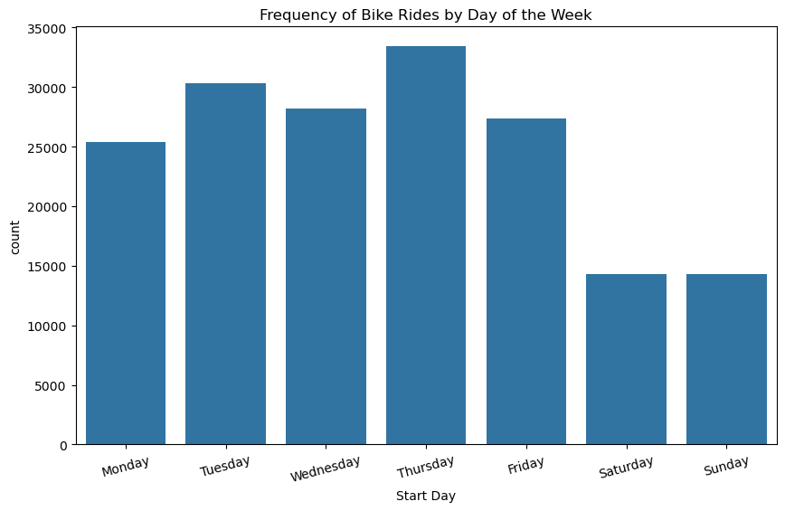

```python
# plotting the frequency of bike rides by the day of the week
plt.figure(figsize=[10,6])
base_color = sb.color_palette()[0]
sb.countplot(data = df_clean, x = 'day', color = base_color)
plt.xlabel('Start Day')
plt.title('Frequency of Bike Rides by Day of the Week')
plt.xticks(rotation=15);
```

The graph clearly indicates that weekdays are the prime time for bike trips

The next focus will be on categorizing users to analyze whether subscribers tend to make more trips than one-time customers.

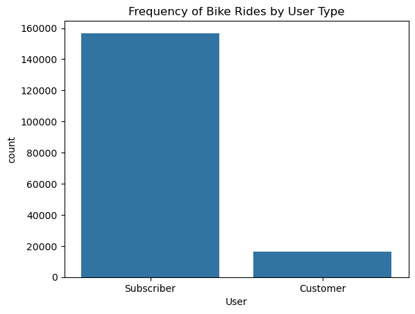

```python
# frequency of bike rides by user type
base_color = sb.color_palette()[0]
user_order = df_clean['user_type'].value_counts().index
sb.countplot(data = df_clean, x = 'user_type', color = base_color, order = user_order)
plt.xlabel('User')
plt.title('Frequency of Bike Rides by User Type');
```

It turns out that program subscribers use bikes more frequently than occasional users. We’ll delve into whether one-time customers embark on longer bike rides than subscribers. This analysis will be featured in the next section through a bivariate exploration.

Next, we'll look at the member age. We'll create am age column from the 'member_birth_year' column

```python
#creating age column from member birth year (2019 - member birth year since this data is from 2019)
df_clean['age'] = (2019 - df_clean['member_birth_year'])
```

```python
# checking this worked
df_clean
```

|  | duration_sec | start_time | end_time | start_station_id | start_station_name | start_station_latitude | start_station_longitude | end_station_id | end_station_name | end_station_latitude | end_station_longitude | bike_id | user_type | member_birth_year | member_gender | bike_share_for_all_trip | duration_min | start_hour | day | age |
| --- | --- | --- | --- | --- | --- | --- | --- | --- | --- | --- | --- | --- | --- | --- | --- | --- | --- | --- | --- | --- |
| 0 | 52185 | 2019-02-28 17:32:10.145 | 2019-03-01 08:01:55.975 | 21.0 | Montgomery St BART Station (Market St at 2nd St) | 37.789625 | -122.400811 | 13.0 | Commercial St at Montgomery St | 37.794231 | -122.402923 | 4902 | Customer | 1984 | Male | No | 869.750000 | 17 | Thursday | 35 |
| 1 | 61854 | 2019-02-28 12:13:13.218 | 2019-03-01 05:24:08.146 | 86.0 | Market St at Dolores St | 37.769305 | -122.426826 | 3.0 | Powell St BART Station (Market St at 4th St) | 37.786375 | -122.404904 | 5905 | Customer | 1972 | Male | No | 1030.900000 | 12 | Thursday | 47 |
| 2 | 36490 | 2019-02-28 17:54:26.010 | 2019-03-01 04:02:36.842 | 375.0 | Grove St at Masonic Ave | 37.774836 | -122.446546 | 70.0 | Central Ave at Fell St | 37.773311 | -122.444293 | 6638 | Subscriber | 1989 | Other | No | 608.166667 | 17 | Thursday | 30 |
| 3 | 1585 | 2019-02-28 23:54:18.549 | 2019-03-01 00:20:44.074 | 7.0 | Frank H Ogawa Plaza | 37.804562 | -122.271738 | 222.0 | 10th Ave at E 15th St | 37.792714 | -122.248780 | 4898 | Subscriber | 1974 | Male | Yes | 26.416667 | 23 | Thursday | 45 |
| 4 | 1793 | 2019-02-28 23:49:58.632 | 2019-03-01 00:19:51.760 | 93.0 | 4th St at Mission Bay Blvd S | 37.770407 | -122.391198 | 323.0 | Broadway at Kearny | 37.798014 | -122.405950 | 5200 | Subscriber | 1959 | Male | No | 29.883333 | 23 | Thursday | 60 |
| ... | ... | ... | ... | ... | ... | ... | ... | ... | ... | ... | ... | ... | ... | ... | ... | ... | ... | ... | ... | ... |
| 173267 | 480 | 2019-02-01 00:04:49.724 | 2019-02-01 00:12:50.034 | 27.0 | Beale St at Harrison St | 37.788059 | -122.391865 | 324.0 | Union Square (Powell St at Post St) | 37.788300 | -122.408531 | 4832 | Subscriber | 1996 | Male | No | 8.000000 | 0 | Friday | 23 |
| 173268 | 313 | 2019-02-01 00:05:34.744 | 2019-02-01 00:10:48.502 | 21.0 | Montgomery St BART Station (Market St at 2nd St) | 37.789625 | -122.400811 | 66.0 | 3rd St at Townsend St | 37.778742 | -122.392741 | 4960 | Subscriber | 1984 | Male | No | 5.216667 | 0 | Friday | 35 |
| 173269 | 141 | 2019-02-01 00:06:05.549 | 2019-02-01 00:08:27.220 | 278.0 | The Alameda at Bush St | 37.331932 | -121.904888 | 277.0 | Morrison Ave at Julian St | 37.333658 | -121.908586 | 3824 | Subscriber | 1990 | Male | Yes | 2.350000 | 0 | Friday | 29 |
| 173270 | 139 | 2019-02-01 00:05:34.360 | 2019-02-01 00:07:54.287 | 220.0 | San Pablo Ave at MLK Jr Way | 37.811351 | -122.273422 | 216.0 | San Pablo Ave at 27th St | 37.817827 | -122.275698 | 5095 | Subscriber | 1988 | Male | No | 2.316667 | 0 | Friday | 31 |
| 173271 | 271 | 2019-02-01 00:00:20.636 | 2019-02-01 00:04:52.058 | 24.0 | Spear St at Folsom St | 37.789677 | -122.390428 | 37.0 | 2nd St at Folsom St | 37.785000 | -122.395936 | 1057 | Subscriber | 1989 | Male | No | 4.516667 | 0 | Friday | 30 |

173272 rows × 20 columns

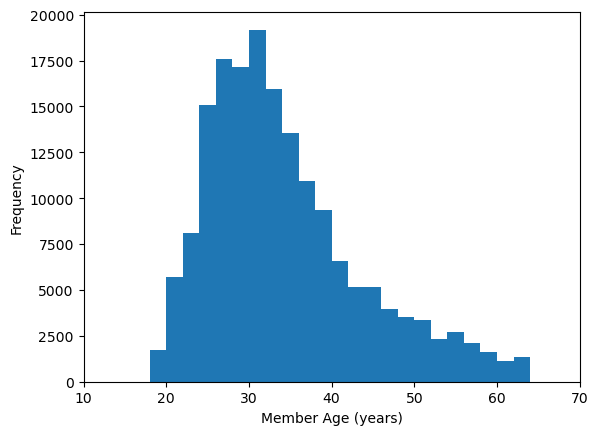

```python
# plotting age distribution
bin_edges = np.arange (10, df_clean['age'].max()+2, 2)
plt.hist(data = df_clean, x = 'age', bins = bin_edges)
plt.xlim(10, 70)
plt.xlabel('Member Age (years)')
plt.ylabel('Frequency');
```

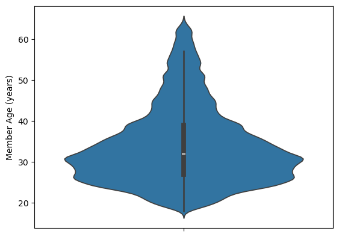

```python
sb.violinplot(data = df_clean, y = 'age')
plt.ylabel('Member Age (years)');
```

The graphs above indicate a noticeable peak around the age of 30.

Next, we’ll analyze gender to determine if one demographic uses FordGo Bikes more than the others.

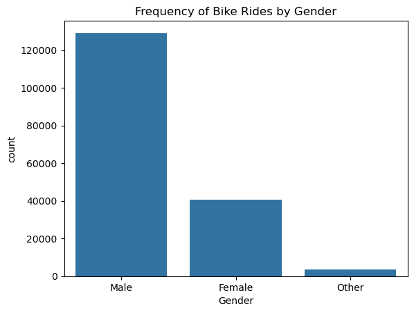

```python
# plotting gender
base_color = sb.color_palette()[0]
gender_order = df_clean['member_gender'].value_counts().index
sb.countplot(data = df_clean, x = 'member_gender', color = base_color, order = gender_order)
plt.xlabel('Gender')
plt.title('Frequency of Bike Rides by Gender');
```

The data shows that a significant number of bike riders are male. We will later examine how gender impacts the length of bike trips.

We will now focus on examining the number of bike trips that were part of the Bike Share for All program.

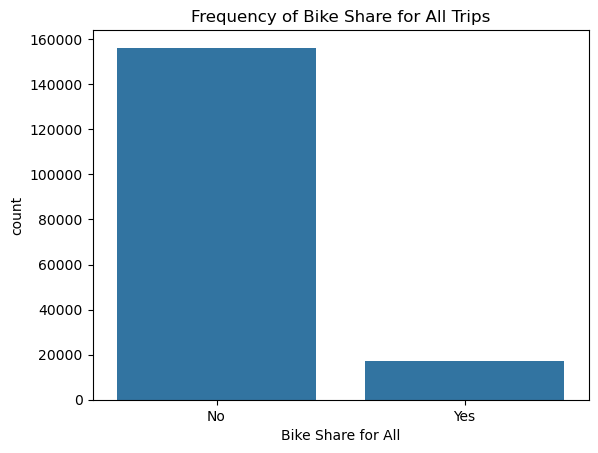

```python
base_color = sb.color_palette()[0]
share_order = df_clean['bike_share_for_all_trip'].value_counts().index
sb.countplot(data = df_clean, x = 'bike_share_for_all_trip', color = base_color, order = share_order)
plt.xlabel('Bike Share for All')
plt.title('Frequency of Bike Share for All Trips');
```

The data above indicates that most trips were not part of the Bike Share for All program.

In the final part of the univariate exploration, we will calculate the distance using the provided start and end longitude and latitude coordinates.

```python
def haversine_np(start_station_longitude, start_station_latitude, end_station_longitude, end_station_latitude):
    """
    Calculate the great circle distance between two points
    on the earth (specified in decimal degrees).
    All args must be of equal length.
    """
    # Convert decimal degrees to radians
    start_station_longitude, start_station_latitude, end_station_longitude, end_station_latitude = map(np.radians,
        [start_station_longitude, start_station_latitude, end_station_longitude, end_station_latitude])

    # Differences in coordinates
    dlon = end_station_longitude - start_station_longitude
    dlat = end_station_latitude - start_station_latitude

    # Haversine formula
    a = np.sin(dlat/2.0)**2 + np.cos(start_station_latitude) * np.cos(end_station_latitude) * np.sin(dlon/2.0)**2
    c = 2 * np.arctan2(np.sqrt(a), np.sqrt(1 - a))  # Using arctan2 for stability

    # Radius of the Earth in kilometers
    radius_earth_km = 6371.0
    km = radius_earth_km * c

    return km
```

We'll create a distance column

```python
# creating a distance column
df_clean['distance'] = haversine_np(df_clean['start_station_longitude'],df_clean['start_station_latitude'],df_clean['end_station_longitude'],df_clean['end_station_latitude'])
```

```python
# checking that this worked
df_clean
```

|  | duration_sec | start_time | end_time | start_station_id | start_station_name | start_station_latitude | start_station_longitude | end_station_id | end_station_name | end_station_latitude | ... | bike_id | user_type | member_birth_year | member_gender | bike_share_for_all_trip | duration_min | start_hour | day | age | distance |
| --- | --- | --- | --- | --- | --- | --- | --- | --- | --- | --- | --- | --- | --- | --- | --- | --- | --- | --- | --- | --- | --- |
| 0 | 52185 | 2019-02-28 17:32:10.145 | 2019-03-01 08:01:55.975 | 21.0 | Montgomery St BART Station (Market St at 2nd St) | 37.789625 | -122.400811 | 13.0 | Commercial St at Montgomery St | 37.794231 | ... | 4902 | Customer | 1984 | Male | No | 869.750000 | 17 | Thursday | 35 | 0.544709 |
| 1 | 61854 | 2019-02-28 12:13:13.218 | 2019-03-01 05:24:08.146 | 86.0 | Market St at Dolores St | 37.769305 | -122.426826 | 3.0 | Powell St BART Station (Market St at 4th St) | 37.786375 | ... | 5905 | Customer | 1972 | Male | No | 1030.900000 | 12 | Thursday | 47 | 2.704545 |
| 2 | 36490 | 2019-02-28 17:54:26.010 | 2019-03-01 04:02:36.842 | 375.0 | Grove St at Masonic Ave | 37.774836 | -122.446546 | 70.0 | Central Ave at Fell St | 37.773311 | ... | 6638 | Subscriber | 1989 | Other | No | 608.166667 | 17 | Thursday | 30 | 0.260739 |
| 3 | 1585 | 2019-02-28 23:54:18.549 | 2019-03-01 00:20:44.074 | 7.0 | Frank H Ogawa Plaza | 37.804562 | -122.271738 | 222.0 | 10th Ave at E 15th St | 37.792714 | ... | 4898 | Subscriber | 1974 | Male | Yes | 26.416667 | 23 | Thursday | 45 | 2.409301 |
| 4 | 1793 | 2019-02-28 23:49:58.632 | 2019-03-01 00:19:51.760 | 93.0 | 4th St at Mission Bay Blvd S | 37.770407 | -122.391198 | 323.0 | Broadway at Kearny | 37.798014 | ... | 5200 | Subscriber | 1959 | Male | No | 29.883333 | 23 | Thursday | 60 | 3.332203 |
| ... | ... | ... | ... | ... | ... | ... | ... | ... | ... | ... | ... | ... | ... | ... | ... | ... | ... | ... | ... | ... | ... |
| 173267 | 480 | 2019-02-01 00:04:49.724 | 2019-02-01 00:12:50.034 | 27.0 | Beale St at Harrison St | 37.788059 | -122.391865 | 324.0 | Union Square (Powell St at Post St) | 37.788300 | ... | 4832 | Subscriber | 1996 | Male | No | 8.000000 | 0 | Friday | 23 | 1.464766 |
| 173268 | 313 | 2019-02-01 00:05:34.744 | 2019-02-01 00:10:48.502 | 21.0 | Montgomery St BART Station (Market St at 2nd St) | 37.789625 | -122.400811 | 66.0 | 3rd St at Townsend St | 37.778742 | ... | 4960 | Subscriber | 1984 | Male | No | 5.216667 | 0 | Friday | 35 | 1.402716 |
| 173269 | 141 | 2019-02-01 00:06:05.549 | 2019-02-01 00:08:27.220 | 278.0 | The Alameda at Bush St | 37.331932 | -121.904888 | 277.0 | Morrison Ave at Julian St | 37.333658 | ... | 3824 | Subscriber | 1990 | Male | Yes | 2.350000 | 0 | Friday | 29 | 0.379066 |
| 173270 | 139 | 2019-02-01 00:05:34.360 | 2019-02-01 00:07:54.287 | 220.0 | San Pablo Ave at MLK Jr Way | 37.811351 | -122.273422 | 216.0 | San Pablo Ave at 27th St | 37.817827 | ... | 5095 | Subscriber | 1988 | Male | No | 2.316667 | 0 | Friday | 31 | 0.747282 |
| 173271 | 271 | 2019-02-01 00:00:20.636 | 2019-02-01 00:04:52.058 | 24.0 | Spear St at Folsom St | 37.789677 | -122.390428 | 37.0 | 2nd St at Folsom St | 37.785000 | ... | 1057 | Subscriber | 1989 | Male | No | 4.516667 | 0 | Friday | 30 | 0.710395 |

173272 rows × 21 columns

Now lets check for outliers

```python
df_clean.distance.describe()
```

```
count    173272.000000
mean          1.691558
std           1.096204
min           0.000000
25%           0.910955
50%           1.430675
75%           2.225687
max          69.469241
Name: distance, dtype: float64
```

```python
df_clean.query("distance > 20")
```

|  | duration_sec | start_time | end_time | start_station_id | start_station_name | start_station_latitude | start_station_longitude | end_station_id | end_station_name | end_station_latitude | ... | bike_id | user_type | member_birth_year | member_gender | bike_share_for_all_trip | duration_min | start_hour | day | age | distance |
| --- | --- | --- | --- | --- | --- | --- | --- | --- | --- | --- | --- | --- | --- | --- | --- | --- | --- | --- | --- | --- | --- |
| 105822 | 6945 | 2019-02-12 14:28:44.402 | 2019-02-12 16:24:30.158 | 21.0 | Montgomery St BART Station (Market St at 2nd St) | 37.789625 | -122.400811 | 300.0 | Palm St at Willow St | 37.317298 | ... | 4780 | Subscriber | 1985 | Female | No | 115.75 | 14 | Tuesday | 34 | 69.469241 |

1 rows × 21 columns

In this section, we'll remove the outliers

```python
df_clean = df_clean.drop(df_clean[df_clean.distance > 20].index)
```

```python
df_clean.distance.describe()
```

```
count    173271.000000
mean          1.691167
std           1.084047
min           0.000000
25%           0.910955
50%           1.430675
75%           2.225687
max          15.673955
Name: distance, dtype: float64
```

Lets see plot the distance distribution

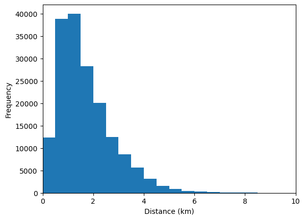

```python
# plotting distance distribution
bin_edges = np.arange (0, df_clean['distance'].max()+0.5, 0.5)
plt.hist(data = df_clean, x = 'distance', bins = bin_edges)
plt.xlabel('Distance (km)')
plt.xlim(0,10)
plt.ylabel('Frequency');
```

Here, we see the frequency distribution of distances traveled, with most trips covering between 0 and 2 kilometers, and the frequency significantly decreasing for longer distances.

### Discuss the distribution(s) of your variable(s) of interest. Were there any unusual points? Did you need to perform any transformations?

> The duration of bike trips was highly skewed to the right, so a log scale was applied to create a log-normal distribution. To enhance comprehension, the duration of bike trips in minutes was added to the dataset. The resulting graph clearly indicates that most bike rides are under 30 minutes, with an average duration around 9-10 minutes.

> Additionally, a distance column was created using longitude and latitude data, revealing that the majority of bike trips were under 2 km.

### Of the features you investigated, were there any unusual distributions? Did you perform any operations on the data to tidy, adjust, or change the form of the data? If so, why did you do this?

> The time of day and day of the week were examined, indicating that bikes were primarily used for commuting, with peak usage occurring from 07:00-09:00 and 16:00-19:00 on weekdays.

> An age column was included to assess the ages of members. The analysis showed a peak of riders around 30 years old. To tidy the data, individuals over the age of 65 were removed, representing the top 1% of the dataset.

> Moreover, it was observed that there were more subscribers than customers taking bike trips, and a higher number of male riders compared to female or other categories. Most trips were not part of the bike share for all trip scheme.

## Bivariate Exploration

> We will now embark on a bivariate analysis to examine potential relationships within the data.

```python
df_clean.info()
```

```
<class 'pandas.core.frame.DataFrame'>
Index: 173271 entries, 0 to 173271
Data columns (total 21 columns):
 #   Column                   Non-Null Count   Dtype
---  ------                   --------------   -----
 0   duration_sec             173271 non-null  int64
 1   start_time               173271 non-null  datetime64[ns]
 2   end_time                 173271 non-null  datetime64[ns]
 3   start_station_id         173271 non-null  object
 4   start_station_name       173271 non-null  object
 5   start_station_latitude   173271 non-null  float64
 6   start_station_longitude  173271 non-null  float64
 7   end_station_id           173271 non-null  object
 8   end_station_name         173271 non-null  object
 9   end_station_latitude     173271 non-null  float64
 10  end_station_longitude    173271 non-null  float64
 11  bike_id                  173271 non-null  object
 12  user_type                173271 non-null  category
 13  member_birth_year        173271 non-null  int64
 14  member_gender            173271 non-null  category
 15  bike_share_for_all_trip  173271 non-null  category
 16  duration_min             173271 non-null  float64
 17  start_hour               173271 non-null  int64
 18  day                      173271 non-null  category
 19  age                      173271 non-null  int64
 20  distance                 173271 non-null  float64
dtypes: category(4), datetime64[ns](2), float64(6), int64(4), object(5)
memory usage: 24.5+ MB
```

We'll designate numeric and categorical variables to simplify plotting.

```python
# assigning numeric and categoric variables
numeric_vars = ['duration_min', 'age', 'distance']
categoric_vars = ['member_gender', 'user_type', 'bike_share_for_all_trip', 'day', 'start_hour']
```

To start, we will analyze the numeric variables to uncover any existing relationships or correlations.

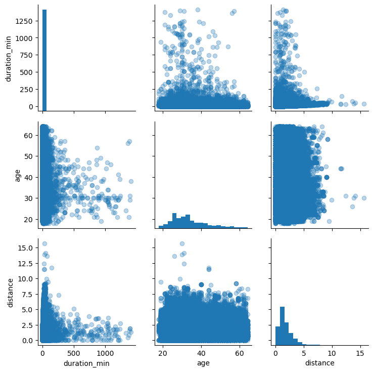

```python
g = sb.PairGrid(data = df_clean, vars = numeric_vars)
g = g.map_diag(plt.hist, bins = 20);
g.map_offdiag(plt.scatter, alpha=0.3)
```

The plots indicate that there are no strong correlations among the numeric variables. We will investigate the relationships between the numeric and categorical variables, as well as those between different categorical variables.

#### Duration Min

We will look at the relationship between the duration of bike trips (measured in minutes) among other features

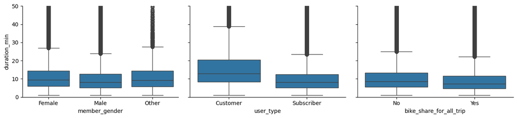

```python
def boxgrid(x, y, **kwargs):
    default_color = sb.color_palette()[0]
    # Call boxplot with explicit parameters
    sb.boxplot(x=x, y=y, color=default_color, **{k: v for k, v in kwargs.items() if k != 'color'})

plt.figure(figsize=[16, 16])
g = sb.PairGrid(data=df_clean, y_vars='duration_min', x_vars=['member_gender', 'user_type', 'bike_share_for_all_trip'],
                height=3, aspect=1.5)
plt.ylim(0, 50)
g.map(boxgrid)
plt.show()
```

The plot clearly shows that, on average, females and individuals identifying as "other" take longer bike trips than males. Interestingly, customers tend to takelonger trips than subscribers, suggesting that when customers opt for a one-time ride, they go for longer distances. Additionally, the bike share program does not significantly influence trip duration, so it will not be considered in the remainder of the analysis.

Next, we will explore the features associated with the time of day and day of the week

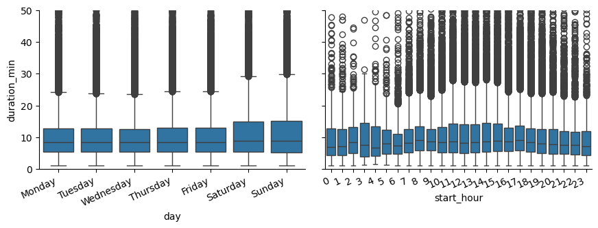

```python
def boxgrid(x, y, **kwargs):
    default_color = sb.color_palette()[0]
    # Call boxplot with explicit parameters
    sb.boxplot(x=x, y=y, color=default_color, **{k: v for k, v in kwargs.items() if k != 'color'})

plt.figure(figsize=[16, 16])
g = sb.PairGrid(data=df_clean, y_vars='duration_min', x_vars=['day', 'start_hour'],
                height=3, aspect=1.5)
plt.ylim(0, 50)

g.map(boxgrid)

# Rotate x-axis labels properly
for ax in g.axes.flatten():
    # Get current tick positions
    ticks = ax.get_xticks()
    ax.set_xticks(ticks)  # Ensure ticks are set
    ax.set_xticklabels(ax.get_xticklabels(), rotation=25, ha='right')

plt.show();
```

### Distance

We will take a brief look at the other features and how they relate to each other.

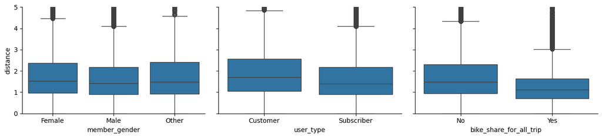

```python
def boxgrid(x, y, **kwargs):
    default_color = sb.color_palette()[0]
    # Call boxplot with explicit parameters
    sb.boxplot(x=x, y=y, color=default_color, **{k: v for k, v in kwargs.items() if k != 'color'})

plt.figure(figsize=[16, 16])
g = sb.PairGrid(data=df_clean, y_vars='distance', x_vars=['member_gender', 'user_type' ,'bike_share_for_all_trip'],
                height=3, aspect=1.5)
plt.ylim(0, 5)
g.map(boxgrid)
plt.show()
```

The analysis above reveals that some variables had a small effect on distance traveled. Notably, females and those who chose 'other' as their gender traveled farther, as did customers compared to subscribers. Furthermore, individuals not engaged in the bike share program also tended to cover longer distances.

We'll take a brief look at distance along with the other variables.

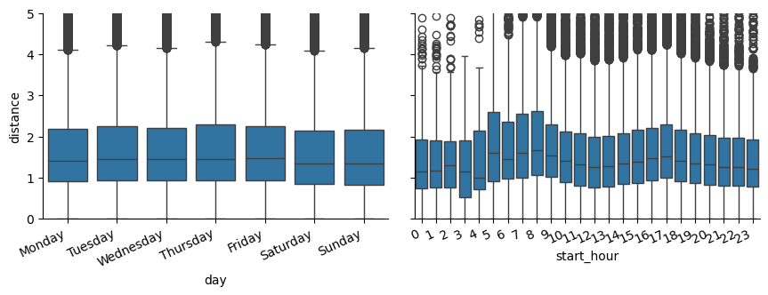

```python
def boxgrid(x, y, **kwargs):
    default_color = sb.color_palette()[0]
    sb.boxplot(x=x, y=y, color=default_color, **{k: v for k, v in kwargs.items() if k != 'color'})

plt.figure(figsize=[16, 16])
g = sb.PairGrid(data=df_clean, y_vars='distance', x_vars=['day', 'start_hour'], height=3, aspect=1.5)

plt.ylim(0, 5)
g.map(boxgrid)

for ax in g.axes.flat:
    # Get the current x-ticks
    ticks = ax.get_xticks()
    # Set the new labels for the current ticks
    ax.set_xticks(ticks)  # Ensure ticks are set before labels
    ax.set_xticklabels(ax.get_xticklabels(), rotation=25, ha='right')

plt.show();
```

The analysis above shows that the day of the week does not really affect the distance traveled. However, it is evident that longer distances were covered in the mornings, particularly between 7 AM and 8 AM. Since there are no compelling relationships regarding distance to explore further, we will now turn our attention to age and its relation to other variables.

### Age

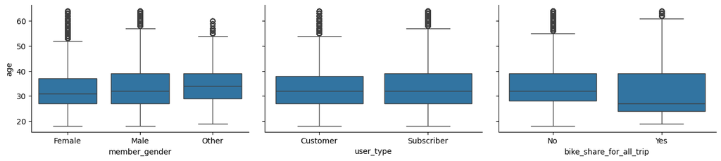

```python
def boxgrid(x, y, **kwargs):
    default_color = sb.color_palette()[0]
    # Call boxplot with explicit parameters
    sb.boxplot(x=x, y=y, color=default_color, **{k: v for k, v in kwargs.items() if k != 'color'})

plt.figure(figsize=[16, 16])
g = sb.PairGrid(data=df_clean, y_vars='age', x_vars=['member_gender', 'user_type', 'bike_share_for_all_trip'],
                height=3, aspect=1.5)

g.map(boxgrid)
plt.show()
```

The boxplot above indicates that the majority of members are in their early 30s, regardless of gender or user type. Participants in the bike share for all scheme tend to be younger on average than those who are not involved.

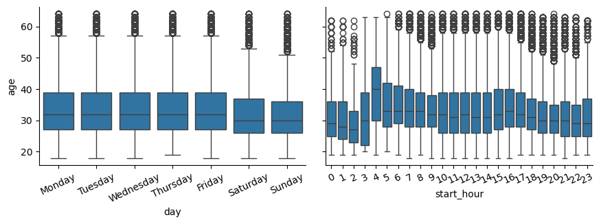

```python
def boxgrid(x, y, **kwargs):
    default_color = sb.color_palette()[0]
    # Call boxplot with explicit parameters
    sb.boxplot(x=x, y=y, color=default_color, **{k: v for k, v in kwargs.items() if k != 'color'})


    plt.xticks(rotation=25)

plt.figure(figsize=[16, 16])
g = sb.PairGrid(data=df_clean, y_vars='age', x_vars=['day', 'start_hour'],
                height=3, aspect=1.5)

g.map(boxgrid)
plt.show()
```

The plot above shows that younger individuals are more likely to take bike trips on weekends. On average, these trips occur late at night and in the early morning hours. We will exclude 'age,' 'distance,' and 'bike share for all' from further analysis, as no significant relationships were identified with these variables.

#### User Type and Gender

Let's examine the relationship between user type and gender.

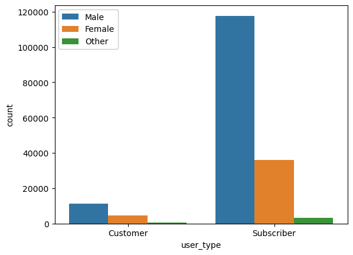

```python
#clustered bar chart
ax = sb.countplot(data = df_clean, x = 'user_type', hue = 'member_gender', hue_order=['Male', 'Female', 'Other'])
ax.legend(loc = 2, framealpha = 1)
```

This clustered bar chart clearly shows that subscribers took more bike rides than customers. The majority of both groups were male.

### Did you observe any interesting relationships between the other features (not the main feature(s) of interest)?

> In terms of the day of the week, younger individuals tended to take more bike trips on weekends. Additionally, trips made very late at night and during the early morning hours were predominantly by younger people.

> From the demographic analysis, it is clear that subscribers took more bike rides than customers, and the majority of both groups were male.

> When examining other features in the dataset, it appears that those who identified as female or other traveled slightly greater distances than males. Customers also traveled slightly further than subscribers on average, and those not involved in the bike share for all scheme tended to cover greater distances as well. Most members are in their early 30s, and those participating in the bike share for all scheme are generally younger than those who are not.

> Moving forward, 'age', 'distance', and 'bike share for all' will not be included in any further analysis, as they do not relate to the features of interest and do not demonstrate strong relationships with other features in the dataset.

## Multivariate Exploration

Next, we'll utilize multivariate plots to examine how the duration and frequency of bike trips relate to various categorical variables, including gender, user type, time of day, and day of the week.

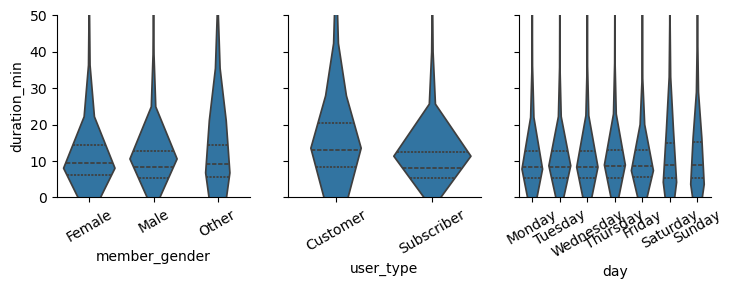

```python
g = sb.PairGrid(data=df_clean, y_vars='duration_min', x_vars=['member_gender', 'user_type', 'day'])
plt.ylim(0, 50)
rotation = 30


for ax in g.fig.axes:
    ax.tick_params(axis='x', rotation=rotation)


default_blue = sb.color_palette()[0]


g.map(sb.violinplot, inner='quartile', color=default_blue)


plt.show()
```

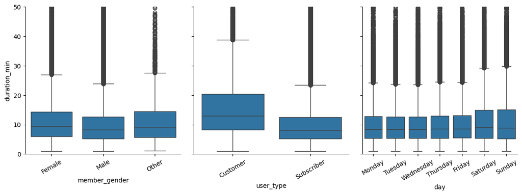

```python
fig = plt.figure(figsize=(12, 8))  # Adjust width and height as needed
g = sb.PairGrid(data=df_clean, y_vars='duration_min', x_vars=['member_gender', 'user_type', 'day'], height=4)  # You can set height per subplot

plt.ylim(0, 50)
rotation = 30


for ax in g.fig.axes:
    ax.tick_params(axis='x', rotation=rotation)


default_blue = sb.color_palette()[0]


g.map(sb.boxplot, color=default_blue)


plt.show()
```

Lets create a clustered bar chart illustrating the relationship between duration, user type, and gender

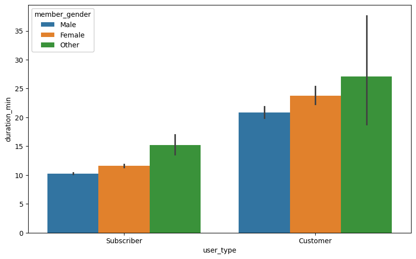

```python
# clustered bar chart
default_colors = ['#1f77b4', '#ff7f0e', '#2ca02c']  # Blue, orange, green
user_type_order = ['Subscriber', 'Customer']
plt.figure(figsize=[10, 6])
ax = sb.barplot(data=df_clean, x='user_type', y='duration_min', hue='member_gender', hue_order=['Male', 'Female', 'Other'], palette=default_colors, order=user_type_order)
ax.legend(loc=2, ncol=1, framealpha=1, title='member_gender')

plt.show()
```

The data indicates that females and others took longer bike trips than males, regardless of their status as customers or subscribers.

A clustered bar chart will be created to explore the relationship between duration, day of the week, and gender.

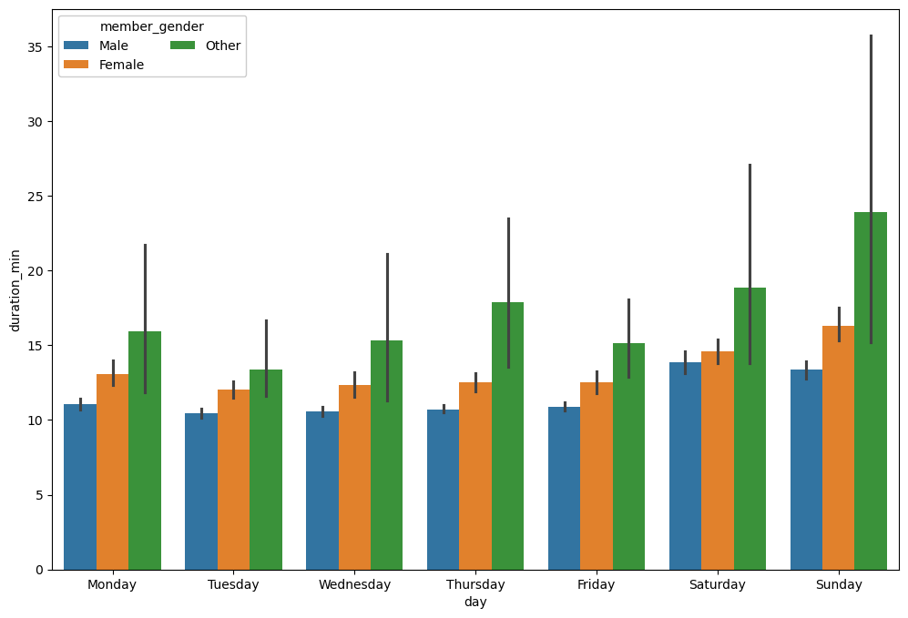

```python
# clustered bar chart
plt.figure(figsize = [12, 8])
ax = sb.barplot(data = df_clean, x = 'day', y = 'duration_min', hue = 'member_gender', hue_order=['Male', 'Female', 'Other'], palette=default_colors)
ax.legend(loc = 2, ncol = 2, framealpha = 1, title = 'member_gender')
```

As shown above, females and individuals identifying as other took longer bike rides than males on each day of the week, and all genders had longer bike trips on weekends.

We will explore the relationship between duration, user type, and the day of the week.

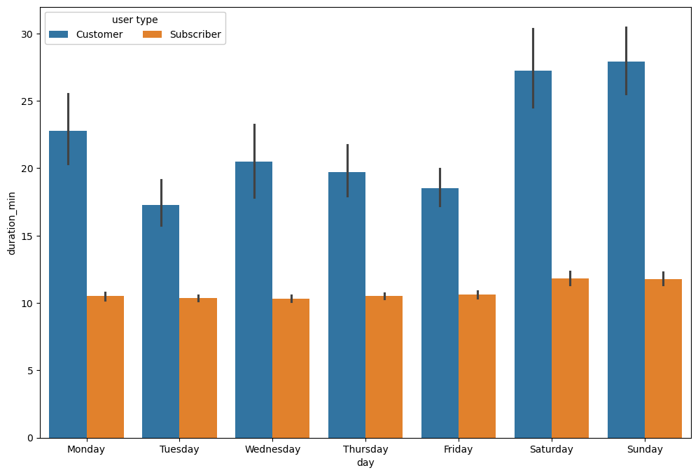

```python
# clustered bar chart
plt.figure(figsize = [12, 8])
ax = sb.barplot(data = df_clean, x = 'day', y = 'duration_min', hue = 'user_type', palette=default_colors[:2])
ax.legend(loc = 2, ncol = 2, framealpha = 1, title = 'user type')
```

Facet Plot  
Let's try a Facet Plot for more clarity

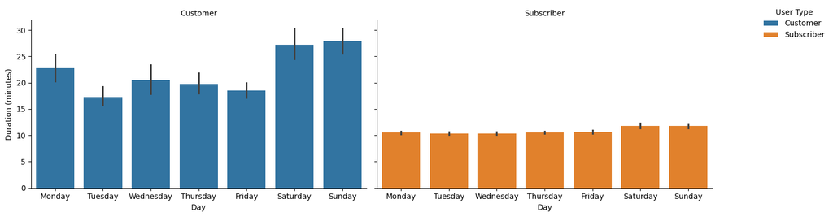

```python
# Define the order for the days
day_order = ['Monday', 'Tuesday', 'Wednesday', 'Thursday', 'Friday', 'Saturday', 'Sunday']

# Convert the 'day' column to a categorical type with the specified order
df_clean['day'] = pd.Categorical(df_clean['day'], categories=day_order, ordered=True)

# Create a FacetGrid
g = sb.FacetGrid(df_clean, col='user_type', col_wrap=2, height=4, aspect=1.5)

# Create the bar plot within each facet
g.map_dataframe(sb.barplot, x='day', y='duration_min', hue='user_type', palette=default_colors[:2], order=day_order)

# Add legends and titles
g.add_legend(title='User Type', bbox_to_anchor=(1.05, 1), loc='upper left')
g.set_axis_labels('Day', 'Duration (minutes)')
g.set_titles(col_template='{col_name}')

# Show the plot
plt.tight_layout()
plt.show()
```

As seen above, customers had longer bike rides than subscribers on every day of the week, and both groups took longer trips on the weekends.

### Frequency of bike trips based on the day of the week and time of day

Next, a heatmap will be created to visualize the frequency of bike trips based on the day of the week and time of day.

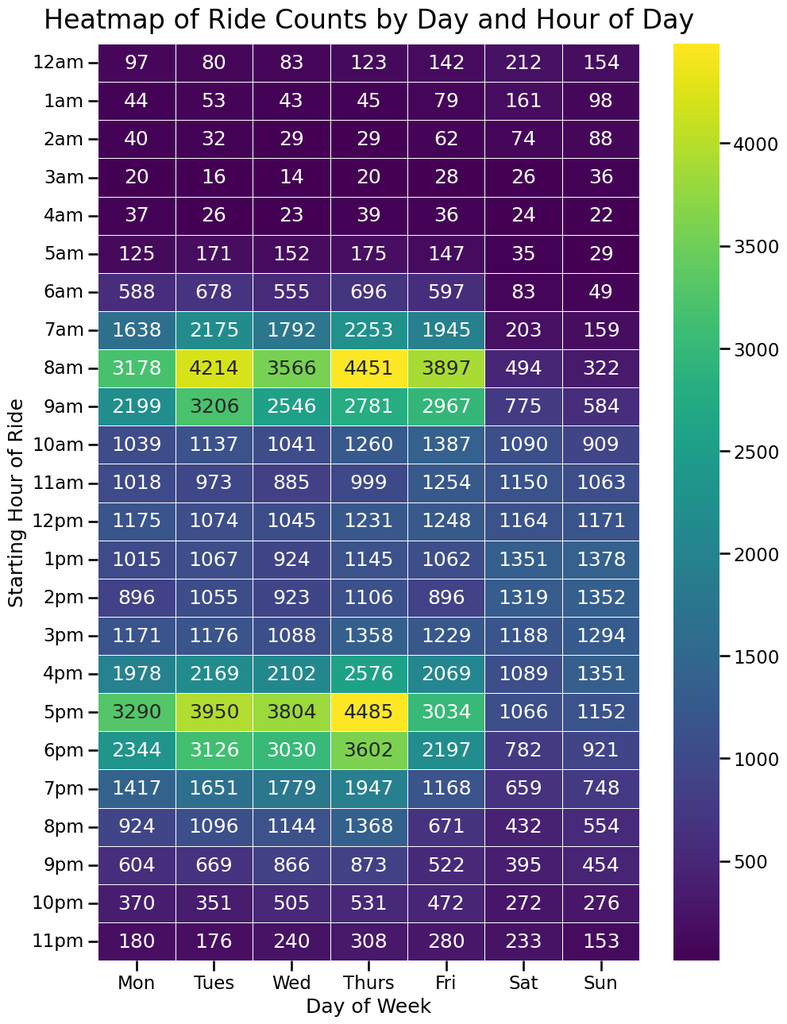

```python
# Generate a second dataframe for visualization
df_clean2 = pd.pivot_table(df_clean[['day', 'start_hour', 'duration_min']], index=['day', 'start_hour'], aggfunc='count')

# Unstacking to achieve the appropriate format for the heatmap.
df_clean3 = df_clean2.unstack(level=0)

# Generate new labels for the hours.
am_hrs = [f"{hr}am" for hr in range(1, 12)]
pm_hrs = [f"{hr}pm" for hr in range(1, 12)]
complete_hrs = ["12am"] + am_hrs + ["12pm"] + pm_hrs

# Abbreviated names for the days of the week
day_abbr = ['Mon', 'Tues', 'Wed', 'Thurs', 'Fri', 'Sat', 'Sun']

# Create the heatmap
sb.set_context("talk")
f, ax = plt.subplots(figsize=(11, 15))
ax = sb.heatmap(df_clean3, annot=True, fmt="d", linewidths=.5, ax=ax, xticklabels=day_abbr, yticklabels=complete_hrs, cmap="viridis")
ax.axes.set_title("Heatmap of Ride Counts by Day and Hour of Day", fontsize=24, y=1.01)
ax.set(xlabel='Day of Week', ylabel='Starting Hour of Ride');



plt.show()
```

The heatmap above reveals that on weekdays, the majority of bike trips occur between 6 AM and 9 AM, as well as 4 PM to 7 PM.

### Time of day, Day of the week, and Duration (minutes)

Now let's visualize the relationship between time of day, day of the week, and bike ride duration.

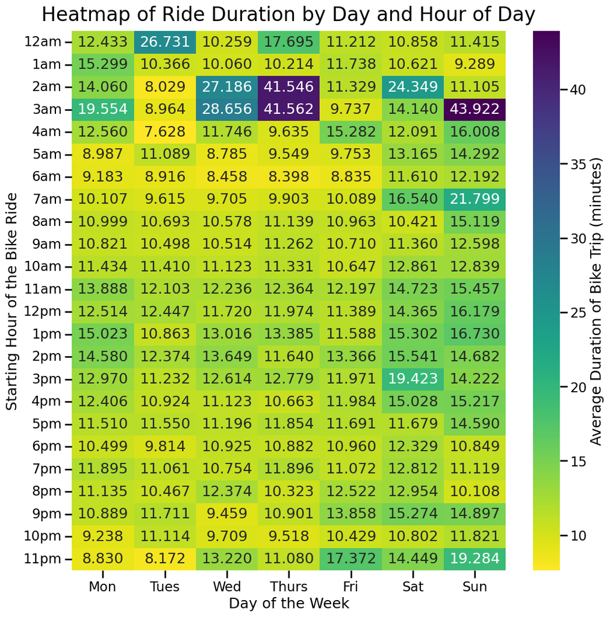

```python
plt.figure(figsize=[12, 12])
cat_means = df_clean.groupby(['day', 'start_hour'], observed=False).mean(numeric_only=True)['duration_min']
cat_means = cat_means.reset_index(name='duration_min_avg')
cat_means = cat_means.pivot(index='start_hour', columns='day', values='duration_min_avg')
sb.heatmap(cat_means, annot=True, fmt='.3f',
           cbar_kws={'label': 'Average Duration of Bike Trip (minutes)'}, xticklabels=day_abbr, yticklabels=complete_hrs, cmap="viridis_r")
plt.xlabel("Day of the Week")
plt.ylabel("Starting Hour of the Bike Ride")
plt.title("Heatmap of Ride Duration by Day and Hour of Day", fontsize=24, y=1.01);
```

The heatmap above shows that bike rides tend to be a bit longer on weekends compared to weekdays. It also reveals that the longest trips, on average, occur during the early morning hours.

### Talk about some of the relationships you observed in this part of the investigation. Were there features that strengthened each other in terms of looking at your feature(s) of interest?

> The investigation into bike trip length and frequency revealed notable relationships, particularly regarding the impact of the day of the week and time of day. The analysis showed that both factors influenced bike trip frequency, with most trips occurring on weekdays during commuting hours, as people utilized bikes for their daily commutes. It was evident that these features supported each other in highlighting patterns of bike usage.

### Were there any interesting or surprising interactions between features?

> While it was expected that more bike trips would occur during commuting hours, it was surprising to find that longer bike trips on average were more common during weekends compared to weekdays. Additionally, an unexpected finding was that some of the longest bike trips during weekdays took place between 1 AM and 3 AM. The data also revealed interesting trends related to gender. All genders tended to take longer bike rides on weekends, but those identifying as 'female' or 'other' consistently took longer trips throughout the week. Furthermore, customers generally took longer trips than subscribers on all days.

## Conclusions

During the exploration, we saw saw that most bike trips lasted under 30 minutes, averaging around 9 minutes, with most trips under 2 km. Users primarily rode during weekdays and commuting hours. Most users were subscribers, but customers tended to take longer trips. The service was most popular among those in their mid-twenties to mid-thirties, with usage declining with age. Males used the service more, but females and those identifying as 'other' had longer trips. Most trips were not part of the Bike Share program. Bivariate analysis showed weak correlations among age, duration, and distance. Longer trips occurred on weekends and in the afternoon. Univariate exploration confirmed that trips were most common during commuting hours, with unexpectedly long trips occurring late at night. Interestingly, females and 'other' users traveled greater distances, as did customers compared to subscribers. Mornings, especially 7-8 AM, saw longer distances traveled. Most users were in their early 30s, with those in the Bike Share for All program being younger. Younger riders were more active on weekends and took late-night trips.

```python
# save as a csv
df_clean.to_csv('2019-fordgobike-data-clean.csv', index = False)
```